# NEPA Decarbonization Technologies Analysis: Deliverable 1

Decarbonization Technologies Project Landscape

Published

August 21, 2026

## Executive Summary

This report aims to create the following set of deliverables:

> Data on number of projects tagged with decarbonization technologies within the dataset: number of projects broken down by technology (e.g., offshore and onshore wind, solar, geothermal, nuclear), lead agency, and location

For a full description of how “decarbonization technologies” are defined and classified in this analysis — including inclusion/exclusion criteria and the overall project universe — see the Project Overview document (last updated 2026-08-21).

# Technology Distribution

**TipKey Findings: Technology**

The first deliverable examines how projects tagged with decarbonization technologies breakdown by technology.

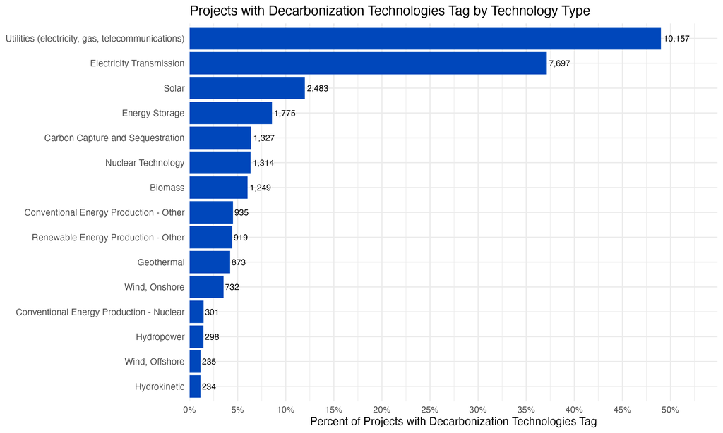

Figure 1: Distribution of projects tagged with decarbonization technologies by technology type. Projects may have multiple technology tags.

A second interesting analysis is to view how the technologies break down by review process.

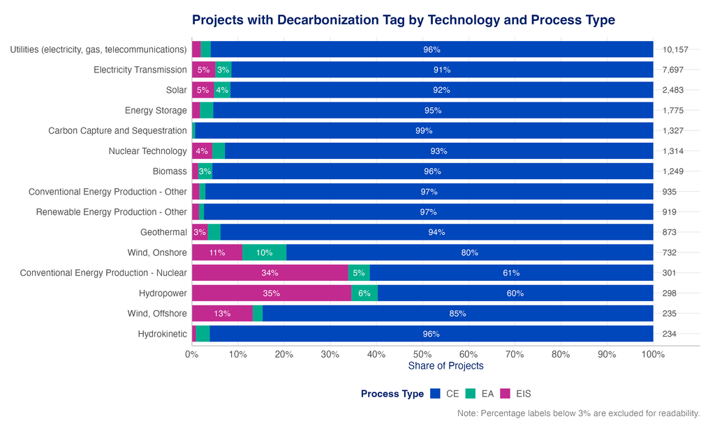

Figure 2: Distribution of projects tagged with decarbonization technologies by technology type and review status. Projects may have multiple technology tags.

# Lead Department and Lead Agency

**TipKey Finding: Agency**

**Department of Energy (DOE) dominates** decarbonization technology NEPA reviews (81% of projects), followed by Interior (17%). DOE processes the vast majority through Categorical Exclusions (CE) (96%).

This section examines project counts by lead department and lead agency. Table 1 reports counts by department and review process, Figure 3 visualizes project counts by department, and Figure 4 shows the process type breakdown for the two agencies with complete data coverage: DOE and BLM.

**Warning**

**Data coverage note:** NEPATEC assembles EIS data from EPA’s governmentwide EIS database (comprehensive for all agencies since 2012) but EA and CE data only from DOE and BLM. Agencies outside these two therefore appear with near-zero EA and CE counts — this reflects a data gap, not actual agency behavior. Process-type mix comparisons are only reliable for DOE and BLM.

The decarbonization technology NEPA portfolio is highly concentrated: DOE alone accounts for roughly four out of every five projects. This reflects both DOE’s broad mission — spanning national labs, weapons facilities, grid modernization, and loan programs — and the fact that NEPATEC’s EA and CE collection is most complete for DOE. The Department of the Interior’s share is driven primarily by BLM’s permitting role for large-scale renewables on federal land.

Table 1: Projects tagged with decarbonization technologies by lead federal department and NEPA process type

| Department | Categorical Exclusion | Environmental Assessment | Environmental Impact Statement | Total |
| --- | --- | --- | --- | --- |
| Department of Energy* | 16,151 | 338 | 241 | 16,730 |
| Department of the Interior* | 3,213 | 212 | 244 | 3,669 |
| Other Independent Agencies | 0 | 1 | 93 | 94 |
| Department of Agriculture | 40 | 11 | 41 | 92 |
| Major Independent Agencies | 0 | 3 | 30 | 33 |
| Department of Defense | 2 | 1 | 15 | 18 |
| Department of Transportation | 2 | 1 | 7 | 10 |
| General Services Administration | 3 | 0 | 7 | 10 |
| Department of Homeland Security | 4 | 1 | 4 | 9 |
| Department of Health and Human Services | 0 | 1 | 3 | 4 |
| Department of Housing and Urban Development | 0 | 1 | 1 | 2 |
| Department of Commerce | 1 | 0 | 0 | 1 |
| Department of State | 0 | 0 | 1 | 1 |
| Department of Veterans Affairs | 0 | 0 | 1 | 1 |
| Department of the Treasury | 0 | 0 | 1 | 1 |
| Total | 19,416 | 570 | 689 | 20,675 |

* Only DOE and DOI have complete CE, EA, and EIS data in NEPATEC 2.0; all other departments are represented only via EPA’s governmentwide EIS database.

The raw project counts in Figure 3 confirm DOE’s dominance in absolute terms. All other departments collectively account for less than 2% of the portfolio, a result that partly reflects genuine mission differences and partly the data coverage gap — those agencies appear almost exclusively through EPA’s EIS database and therefore contribute only EIS records.

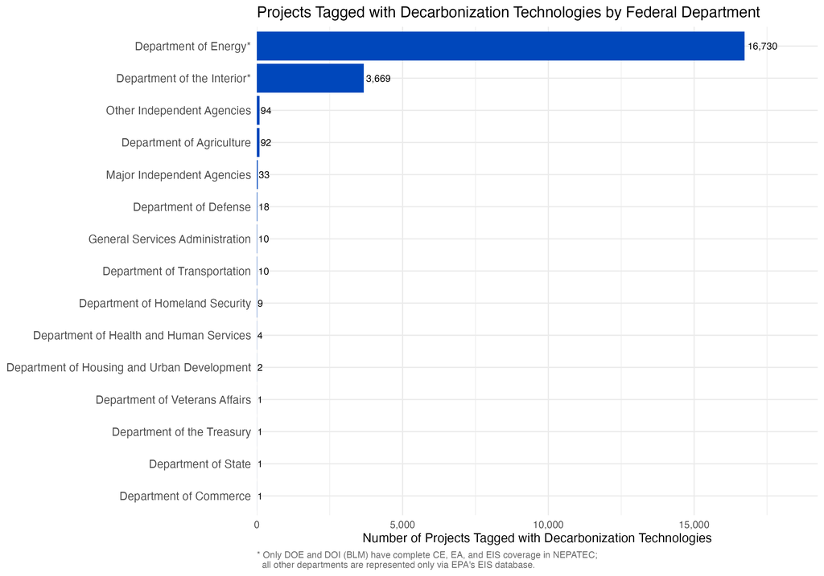

Figure 3: Projects tagged with decarbonization technologies by lead department

Where the coverage data is reliable — DOE and BLM — the process type mix tells a slightly different story for each. DOE processes the overwhelming majority of its decarbonization actions as Categorical Exclusions, consistent with its large volume of routine lab operations, equipment upgrades, and smaller energy projects. BLM, by contrast, processes about 10% of its actions via Environmental Assessments (EA) and Environmental Impact Statements (EIS), reflecting the greater site-specificity and environmental sensitivity of renewable energy siting decisions on federal public lands.

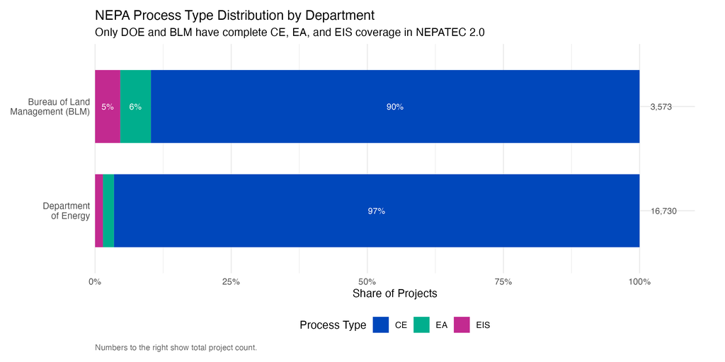

Figure 4: NEPA process type distribution for the two departments with complete CE, EA, and EIS coverage in NEPATEC 2.0: DOE (all sub-agencies) and BLM. Numbers to the right show total project count.

# Geographic Distribution

**TipKey Finding: Geography**

The final deliverable examines geographic location of projects. Table 2 reports project counts by NEPA process type, Figure 5 visualizes that with a state map, and Figure 8 does so by county. [Click here for a complete table](https://docs.google.com/spreadsheets/d/11J6hU15ngCQP-Quk8h2eSkwct7cmq8Zigl_XsDbpsi0/edit?gid=1065723676#gid=1065723676) of project count by county, which is prohibitively large.

## State-Level Distribution

| State | Categorical Exclusion | Environmental Impact Statement | Environmental Assessment | Total |
| --- | --- | --- | --- | --- |
| South Carolina | 2,000 | 16 | 8 | 2,024 |
| Washington | 1,748 | 81 | 43 | 1,872 |
| California | 1,474 | 173 | 87 | 1,734 |
| Oregon | 1,205 | 67 | 31 | 1,303 |
| Colorado | 1,149 | 37 | 34 | 1,220 |
| Idaho | 838 | 74 | 50 | 962 |
| Arizona | 791 | 65 | 88 | 944 |
| Nevada | 791 | 97 | 21 | 909 |
| Wyoming | 638 | 43 | 7 | 688 |
| Texas | 576 | 12 | 14 | 602 |
| New Mexico | 490 | 36 | 13 | 539 |
| New York | 511 | 20 | 8 | 539 |
| Utah | 470 | 38 | 7 | 515 |
| Pennsylvania | 462 | 8 | 6 | 476 |
| Illinois | 439 | 9 | 12 | 460 |
| Montana | 312 | 40 | 6 | 358 |

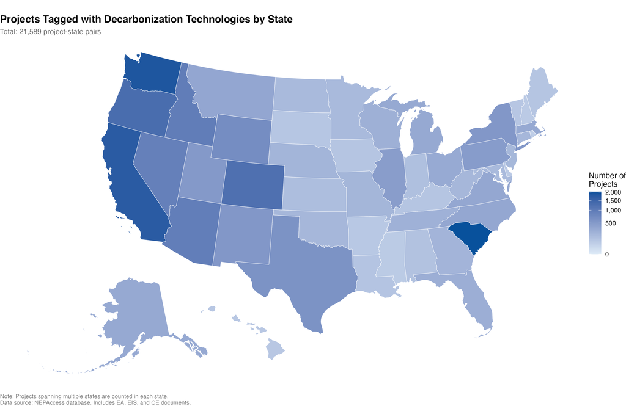

Figure 5: Projects tagged with decarbonization technologies by state. Alaska and Hawaii repositioned for display.

South Carolina clearly sticks out with the number of projects in the state. Click here to explore a [more detailed table](https://docs.google.com/spreadsheets/d/11J6hU15ngCQP-Quk8h2eSkwct7cmq8Zigl_XsDbpsi0/edit?gid=991995876#gid=991995876) of projects there.

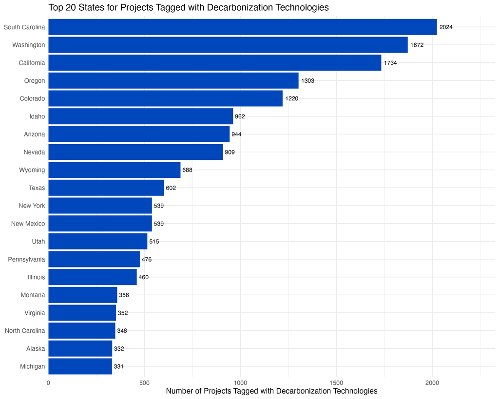

Figure 6: Top 20 states by decarbonization technology project count.

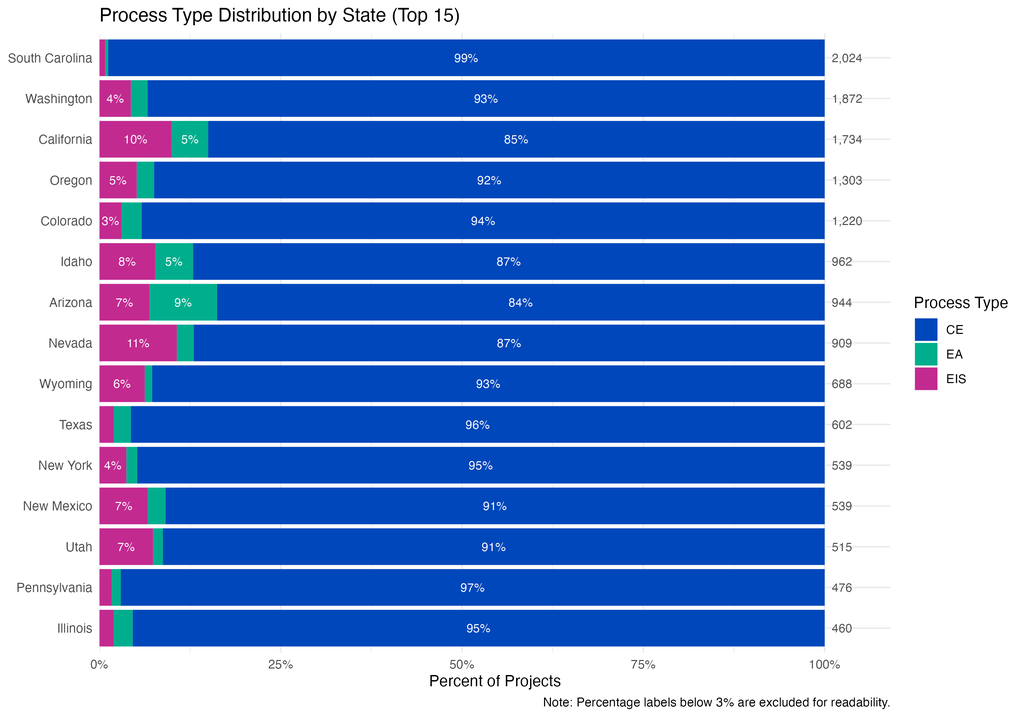

Figure 7: NEPA process type distribution across top 15 states.

## County-Level Distribution

Table 3: County data coverage by NEPA process type

| Process Type | Total Projects | With County Data | Missing County | Recoverable<sup>1</sup> |
| --- | --- | --- | --- | --- |
| CE (Categorical Exclusion) | 19,399 | 8,461 (44%) | 10,938 (56%) | Not recoverable |
| EA (Environmental Assessment) | 573 | 462 (81%) | 111 (19%) | ~109 (98%) |
| EIS (Environmental Impact Statement) | 753 | 486 (65%) | 267 (36%) | ~264 (99%) |
| Total | 20,725 | 9,409 (45%) | 11,316 (55%) | ~373 EA/EIS |

<sup>1</sup> CE projects use legal land descriptions without coordinates, making county recovery infeasible. EA and EIS projects have lat/long coordinates that enable reverse geocoding.

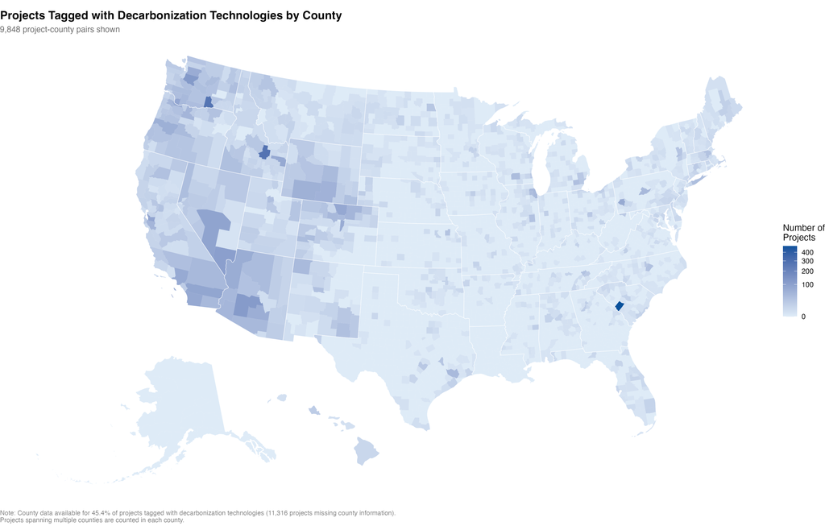

## Process Type by Location by Review Process

The following three maps show county-level project concentration by NEPA process type using a continuous gradient scale. Each map has its own legend calibrated to that process type’s data distribution. CE projects dominate the highest activity counties (particularly in South Carolina and Idaho), while EA and EIS projects show more dispersed, lower-intensity geographic patterns.

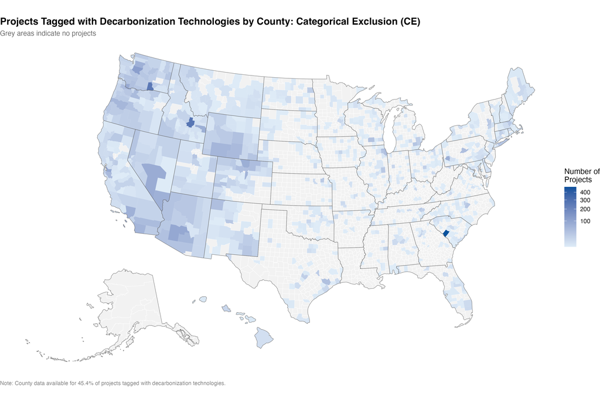

Figure 9: Categorical Exclusion (CE) projects by county.

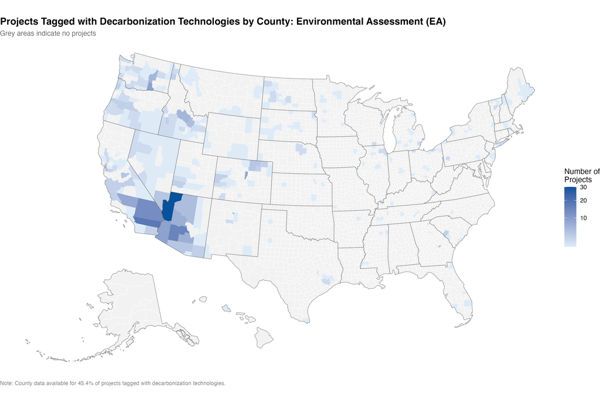

Figure 10: Environmental Assessment (EA) projects by county.

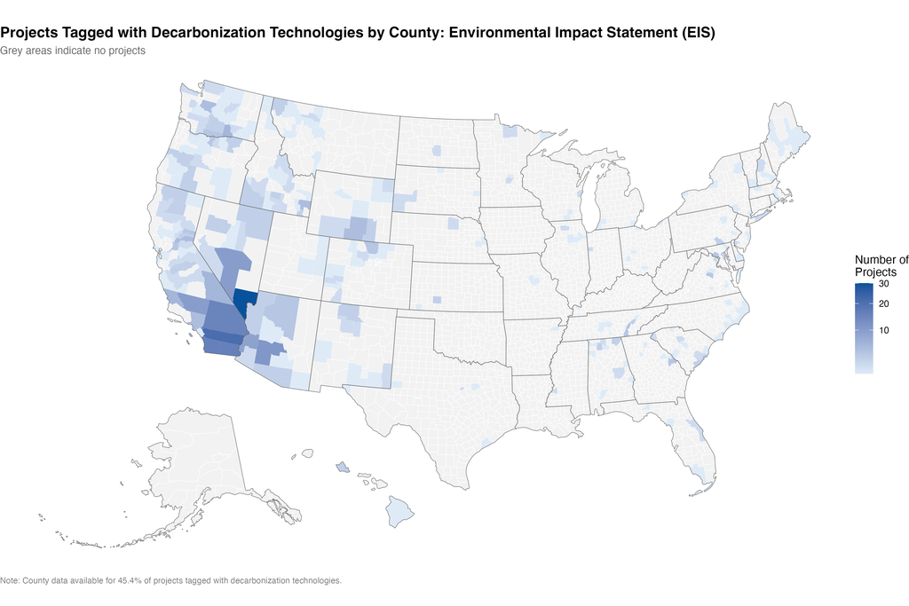

Figure 11: Environmental Impact Statement (EIS) projects by county.

The following three maps (Figure 12, Figure 13, Figure 14) provide an alternative view using Jenks natural breaks classification. Unlike the continuous gradient above, Jenks classification groups counties into classes that mathematically highlight differences between groups[^1]. Each map calculates its own classification breaks based on that process type’s data distribution, making it easier to identify distinct tiers of project activity within each category.

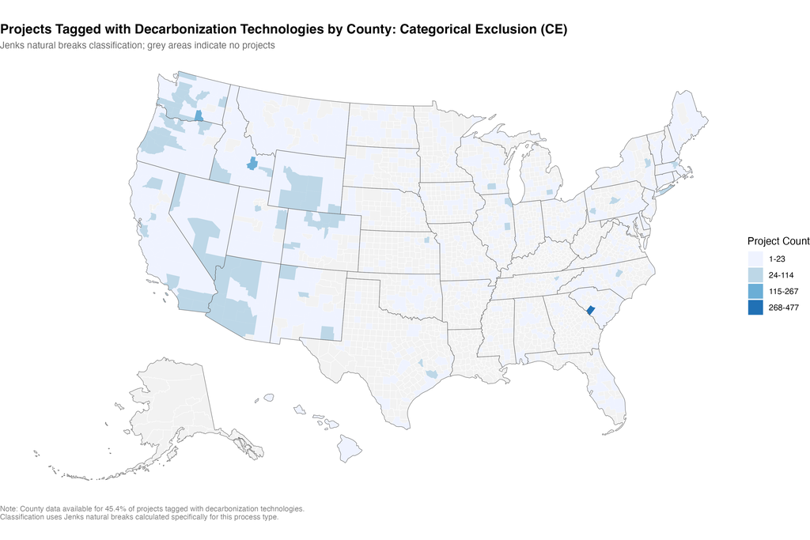

Figure 12: Categorical Exclusion (CE) projects by county using Jenks natural breaks classification.

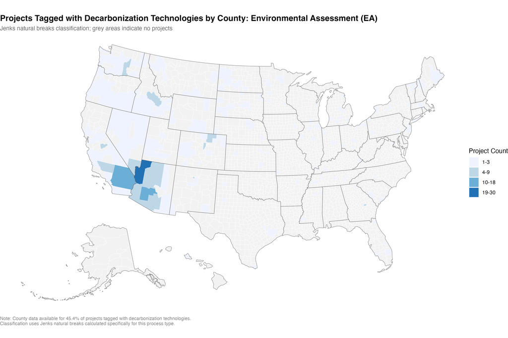

Figure 13: Environmental Assessment (EA) projects by county using Jenks natural breaks classification.

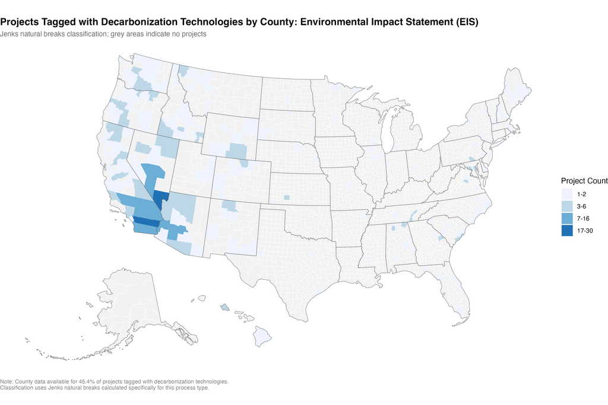

Figure 14: Environmental Impact Statement (EIS) projects by county using Jenks natural breaks classification.

## Deeper Dive into High Project Count Counties

This section examines the projects in counties with the highest project counts for each NEPA process type. The figures show technology distribution across the top 10 counties, while the tables provide a random sample of 20 projects from the top 2 counties. Full project lists are available in the Google Sheet.

### Top Categorical Exclusion (CE) Counties

Figure 15 shows the technology distribution across the top 10 CE counties.

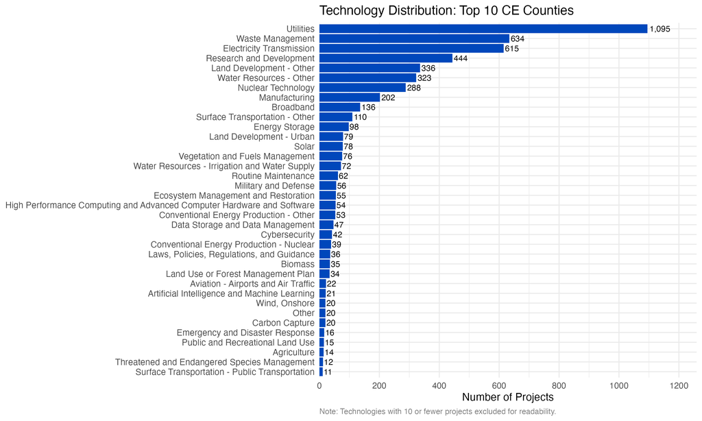

Figure 15: Technology distribution in top 10 CE counties

Table 4 shows a random sample of 20 projects from the two counties with the highest CE counts.

Table 4: Sample of projects in top 2 CE counties (random 20)

| Project Title | Technology | Location |
| --- | --- | --- |
| Fiscal Year (FY)-14 Wireless Test Bed Fiber Optic Cable to Gate 1 and Experimental Breeder Reactor-I (EBR-I) Cell Sites | Broadband, Utilities, Waste Management, Electricity Transmission | Butte, ID |
| Remove Power from Disconnect 7.06 in Building 234-H Room 326 | Electricity Transmission, Utilities, Waste Management | Aiken, SC |
| Function Test Station Process Computer System (PCS) Replacement | Nuclear Technology, High Performance Computing and Advanced Computer Hardware and Software, Data Storage and Data Management | Aiken, SC |
| Benchtop Distillation and Recovery of Volatile Solvents | Research and Development, Waste Management, Biomass | Aiken, SC |
| Installation of Kurz Flowmeter in Plant Air System | Utilities | Aiken, SC |
| Excavation/Replacement of 218-H Cooling Tower Make-up Isolation Valve HQ-234000-DW-V-80.018 | Water Resources - Irrigation and Water Supply, Utilities, Manufacturing | Aiken, SC |
| Materials and Fuels Complex Temporary Office Trailers | Land Development - Other, Utilities, Water Resources - Irrigation and Water Supply, Waste Management | Butte, ID |
| 772-25B Renovation | Land Development - Other, Research and Development, Utilities | Aiken, SC |
| Design and Replace TEF Glovebox Panametrics and Teledyne with Manufacturer Recommended Model | Nuclear Technology | Aiken, SC |
| Rebuild Kamer Valve HTN.153F | Nuclear Technology, Manufacturing, Utilities | Aiken, SC |
| 703-46A Replace Fire Alarm System | Utilities | Aiken, SC |
| Repair of Sinkhole and Remove Grass from East of 234-H Main Side Air Handling Unit | Land Development - Other, Vegetation and Fuels Management, Nuclear Technology | Aiken, SC |
| Liteye CUAS Testing | Research and Development, Military and Defense, Cybersecurity, Aviation - Airports and Air Traffic, Land Development - Other, Utilities, Waste Management | Butte, ID |
| General Building Maintenance Activities in the SRTE Limited Area | Nuclear Technology, Routine Maintenance | Aiken, SC |
| Materials and Fuels Complex (MFC) Fire Water Replacement and Upgrades | Water Resources - Irrigation and Water Supply, Waste Management, Land Development - Other, Utilities, Electricity Transmission | Butte, ID |
| Central Facilities Area (CFA)-696 Compressed Air System Upgrade | Utilities, Manufacturing, Waste Management | Butte, ID |
| Replacement of Air Compressors - Building 775-A | Manufacturing, Nuclear Technology, Utilities | Aiken, SC |
| Providing electrical power to proposed SCDHEC air monitoring location for Environmental Baseline Monitoring for the project | Research and Development, Electricity Transmission | Aiken, SC |
| Unmanned Aerial System Testing | Aviation - Airports and Air Traffic, Research and Development, Electricity Transmission, Land Development - Other, Waste Management, Utilities | Butte, ID |
| Paint 253-1H Switchgear Exterior | Electricity Transmission | Aiken, SC |

### Top Environmental Assessment (EA) Counties

Figure 16 shows the technology distribution across the top 10 EA counties.

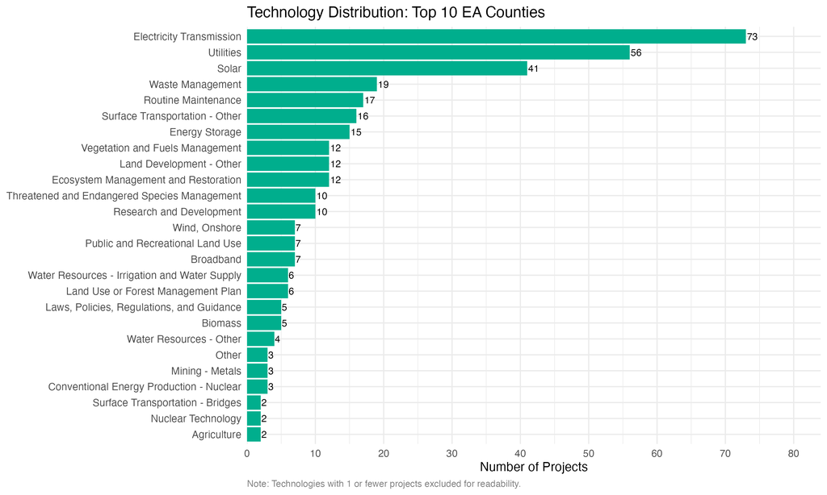

Figure 16: Technology distribution in top 10 EA counties

Table 5 shows a random sample of 20 projects from the two counties with the highest EA counts.

Table 5: Sample of projects in top 2 EA counties (random 20)

| Project Title | Technology | Location |
| --- | --- | --- |
| Easley Renewable Energy Project | Solar, Energy Storage, Electricity Transmission, Waste Management | Riverside, CA |
| IP Athos Renewable Energy Project 220-kV Generation Tie-Line Invasive Plant Management Integrated Weed Management Plan and Pesticide Use Proposal for Construction, Operation, and Maintenance Activitie… | Vegetation and Fuels Management, Electricity Transmission, Solar, Routine Maintenance, Ecosystem Management and Restoration, Threatened and Endangered Species Management | Riverside, CA |
| Arica Solar Project and Victory Pass Solar Project | Solar, Electricity Transmission | Riverside, CA |
| Riverside East Solar Energy Zone, Excavation Pits for Soil Profile Characterization | Research and Development, Solar | Riverside, CA |
| Black Rock Communications Tower and Power Line | Utilities, Broadband, Electricity Transmission | Mohave, AZ |
| Renewal of Happy Jack Rights-of-Way Grants | Utilities, Electricity Transmission, Broadband | Mohave, AZ |
| Desert Harvest Solar Project Integrated Weed Management Plan Implementation for Operations and Maintenance Activities | Solar, Vegetation and Fuels Management, Ecosystem Management and Restoration, Threatened and Endangered Species Management, Laws, Policies, Regulations, and Guidance | Riverside, CA |
| USGS Groundwater Monitoring Well | Water Resources - Other, Mining - Metals, Conventional Energy Production - Nuclear, Research and Development, Ecosystem Management and Restoration | Mohave, AZ |
| Indian Canyon Drive and Bridge Widening | Surface Transportation - Bridges, Surface Transportation - Other, Utilities | Riverside, CA |
| Andrews Farms Right-of-Way | Surface Transportation - Other, Utilities, Routine Maintenance | Mohave, AZ |
| Blythe Mesa Solar Project | Solar, Electricity Transmission | Riverside, CA |
| Sacramento Valley Rights-of-Way Reauthorizations | Electricity Transmission, Utilities, Routine Maintenance | Mohave, AZ |
| West Highway 93 Rights-of-Way Renewals | Electricity Transmission, Utilities | Mohave, AZ |
| Mount Perkins Communications Site - BLM | Utilities, Solar, Land Use or Forest Management Plan, Ecosystem Management and Restoration, Threatened and Endangered Species Management, Routine Maintenance | Mohave, AZ |
| Right-of-Way AZA 037286 | Utilities, Electricity Transmission, Routine Maintenance | Mohave, AZ |
| Crossman Peak Road Right-of-Way | Surface Transportation - Other, Routine Maintenance, Utilities | Mohave, AZ |
| Black Rock Communications Tower and Power Line | Utilities, Broadband, Electricity Transmission | Mohave, AZ |
| Arica and Victory Pass Solar Projects | Solar | Riverside, CA |
| Mesa Wind Repower Project | Wind, Onshore, Electricity Transmission, Waste Management | Riverside, CA |
| Pesticide Use Permit for Riviera Substation | Utilities, Electricity Transmission, Vegetation and Fuels Management, Routine Maintenance | Mohave, AZ |

### Top Environmental Impact Statement (EIS) Counties

Figure 17 shows the technology distribution across the top 10 EIS counties.

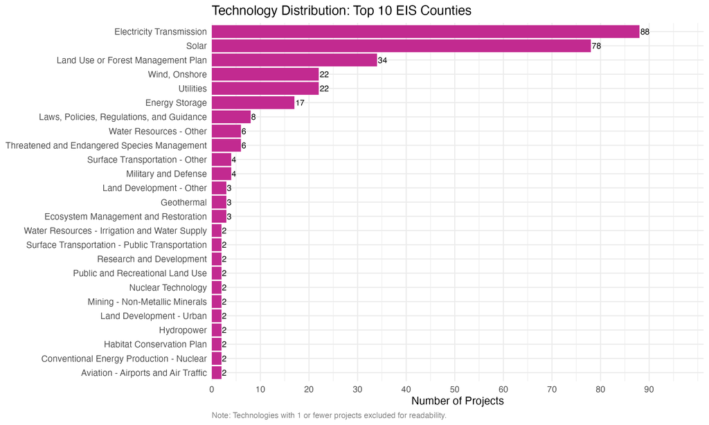

Figure 17: Technology distribution in top 10 EIS counties

Table 6 shows a random sample of 20 projects from the two counties with the highest EIS counts.

Table 6: Sample of projects in top 2 EIS counties (random 20)

| Project Title | Technology | Location |
| --- | --- | --- |
| Palen Solar Project | Solar | Riverside, CA |
| Southern Bighorn Solar Projects | Solar, Energy Storage, Electricity Transmission | Clark, NV |
| Chuckwalla Solar Projects | Solar, Energy Storage, Electricity Transmission | Clark, NV |
| Bonanza Solar Project | Solar, Threatened and Endangered Species Management, Ecosystem Management and Restoration, Land Use or Forest Management Plan | Clark, NV |
| Desert Harvest Solar Project | Solar, Electricity Transmission, Land Use or Forest Management Plan | Riverside, CA |
| Desert Quartzite Solar Project | Solar, Electricity Transmission | Riverside, CA |
| Searchlight Wind Energy Project | Wind, Onshore, Electricity Transmission, Laws, Policies, Regulations, and Guidance | Clark, NV |
| Searchlight Wind Energy Project | Wind, Onshore, Electricity Transmission | Clark, NV |
| Silver State Solar South Project and Proposed Las Vegas Field Office Resource Management Plan Amendment | Solar, Land Use or Forest Management Plan | Clark, NV |
| Crescent Peak Wind Energy Project | Wind, Onshore, Electricity Transmission | Clark, NV |
| Modified Blythe Solar Power Project | Solar, Electricity Transmission | Riverside, CA |
| Arrow Canyon Solar Project | Solar, Energy Storage, Electricity Transmission | Clark, NV |
| Bonanza Solar Project | Solar, Energy Storage, Electricity Transmission, Land Use or Forest Management Plan | Clark, NV |
| Rough Hat Clark Solar Project, Clark County, Nevada | Solar, Energy Storage, Electricity Transmission | Clark, NV |
| McCoy Solar Energy Project | Solar, Land Use or Forest Management Plan, Laws, Policies, Regulations, and Guidance, Electricity Transmission | Riverside, CA |
| Gemini Solar Project | Solar, Electricity Transmission, Land Use or Forest Management Plan, Laws, Policies, Regulations, and Guidance | Clark, NV |
| Rice Solar Energy Project, Riverside County, California | Solar, Electricity Transmission | Riverside, CA |
| Crimson Solar Project | Solar, Electricity Transmission, Land Use or Forest Management Plan | Riverside, CA |
| Gemini Solar Project | Solar, Electricity Transmission | Clark, NV |
| Yahthumb Solar Project | Solar, Energy Storage, Electricity Transmission | Clark, NV |

*Report generated 2026-08-21 | NEPA Decarbonization Technologies Analysis*

## Footnotes

[^1]: It does this by minimizing within-class variance and maximize between-class differences